# **Bank Churn Prediction**

Samir Karandikar

Project Description - Bank Churn Prediction

Objective: Given a Bank customer, build a neural network-based classifier that can determine whether they will leave or not in the next 6 months. Context: Businesses like banks that provide service have to worry about the problem of 'Churn' i.e. customers leaving and joining another service provider. It is important to understand which aspects of the service influence a customer's decision in this regard. Management can concentrate efforts on the improvement of service, keeping in mind these priorities.

```python
import tensorflow as tf
print(tf.__version__)
```

```
2.4.1
```

```python
import matplotlib.pyplot as plt
%matplotlib inline
import warnings
warnings.filterwarnings('ignore')
import pandas as pd
import numpy as np
```

```python
from google.colab import drive
drive.mount('/content/drive')
```

## **1. Read the dataset**

Dataset is read as pandas dataframe df. Please see the explanation of each data variable below:

> - RowNumber: Row number.
> - CustomerId: Unique identification key for different customers.
> - Surname: Surname of the customer
> - Credit Score: Credit score is a measure of an individual's ability to pay back the borrowed amount. It is the numerical representation of their creditworthiness. A credit score is a 3-digit number that falls in the range of 300-900, 900 being the highest.
> - Geography: The country to which the customer belongs.
> - Gender: The gender of the customer.
> - Age: Age of the customer.
> - Tenure: The period of time a customer has been associated with the bank.
> - Balance: The account balance (the amount of money deposited in the bank account) of the customer.
> - NumOfProducts: How many accounts, bank account affiliated products the person has.
> - HasCrCard: Does the customer have a credit card through the bank?
> - IsActiveMember: Subjective, but for the concept
> - EstimatedSalary: Estimated salary of the customer.
> - Exited: Did they leave the bank after all?

```python
# reading the CSV file into pandas dataframe
df = pd.read_csv('/content/drive/My Drive/Colab Notebooks/bank.csv')

pd.isnull(df).count()
```

```
RowNumber          10000
CustomerId         10000
Surname            10000
CreditScore        10000
Geography          10000
Gender             10000
Age                10000
Tenure             10000
Balance            10000
NumOfProducts      10000
HasCrCard          10000
IsActiveMember     10000
EstimatedSalary    10000
Exited             10000
dtype: int64
```

```python
df.dtypes
```

```
RowNumber            int64
CustomerId           int64
Surname             object
CreditScore          int64
Geography           object
Gender              object
Age                  int64
Tenure               int64
Balance            float64
NumOfProducts        int64
HasCrCard            int64
IsActiveMember       int64
EstimatedSalary    float64
Exited               int64
dtype: object
```

### **2. Drop the columns which are unique for all users like IDs (5 points)**

```python
df  = df.drop(['RowNumber','CustomerId','Surname'], axis=1)
```

```python
df.describe().T
```

|  | count | mean | std | min | 25% | 50% | 75% | max |
| --- | --- | --- | --- | --- | --- | --- | --- | --- |
| CreditScore | 10000.0 | 650.528800 | 96.653299 | 350.00 | 584.00 | 652.000 | 718.0000 | 850.00 |
| Age | 10000.0 | 38.921800 | 10.487806 | 18.00 | 32.00 | 37.000 | 44.0000 | 92.00 |
| Tenure | 10000.0 | 5.012800 | 2.892174 | 0.00 | 3.00 | 5.000 | 7.0000 | 10.00 |
| Balance | 10000.0 | 76485.889288 | 62397.405202 | 0.00 | 0.00 | 97198.540 | 127644.2400 | 250898.09 |
| NumOfProducts | 10000.0 | 1.530200 | 0.581654 | 1.00 | 1.00 | 1.000 | 2.0000 | 4.00 |
| HasCrCard | 10000.0 | 0.705500 | 0.455840 | 0.00 | 0.00 | 1.000 | 1.0000 | 1.00 |
| IsActiveMember | 10000.0 | 0.515100 | 0.499797 | 0.00 | 0.00 | 1.000 | 1.0000 | 1.00 |
| EstimatedSalary | 10000.0 | 100090.239881 | 57510.492818 | 11.58 | 51002.11 | 100193.915 | 149388.2475 | 199992.48 |
| Exited | 10000.0 | 0.203700 | 0.402769 | 0.00 | 0.00 | 0.000 | 0.0000 | 1.00 |

## **3.Perform bivariate analysis and give your insights from the same (5 points)**

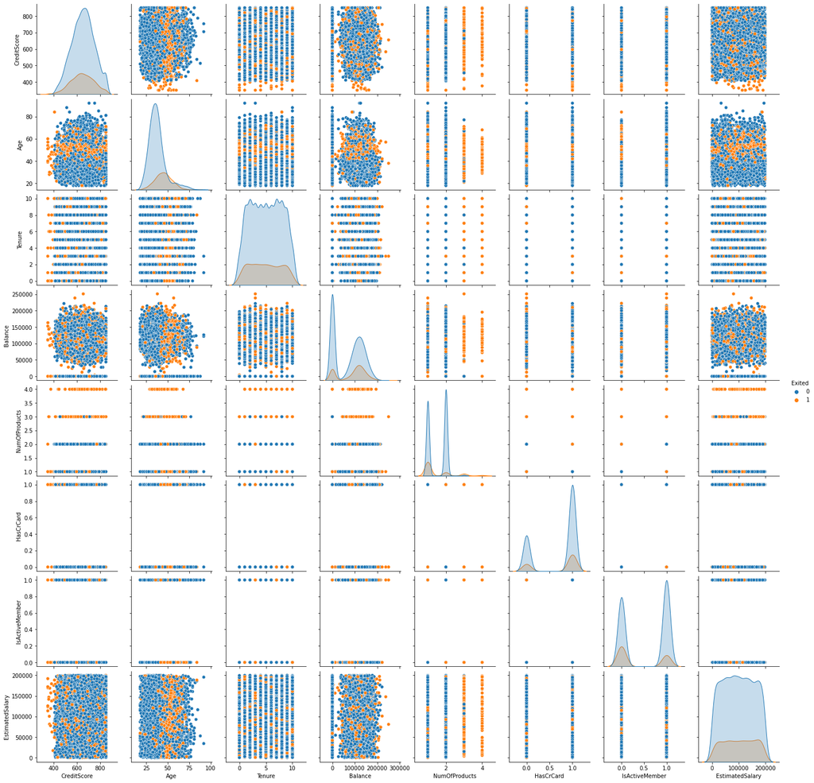

```python
import seaborn as sns

sns.pairplot(data=df, hue = 'Exited')
```

```python
df['Geography'].value_counts()
```

```
France     5014
Germany    2509
Spain      2477
Name: Geography, dtype: int64
```

```python
df['Gender'].value_counts()
```

```
Male      5457
Female    4543
Name: Gender, dtype: int64
```

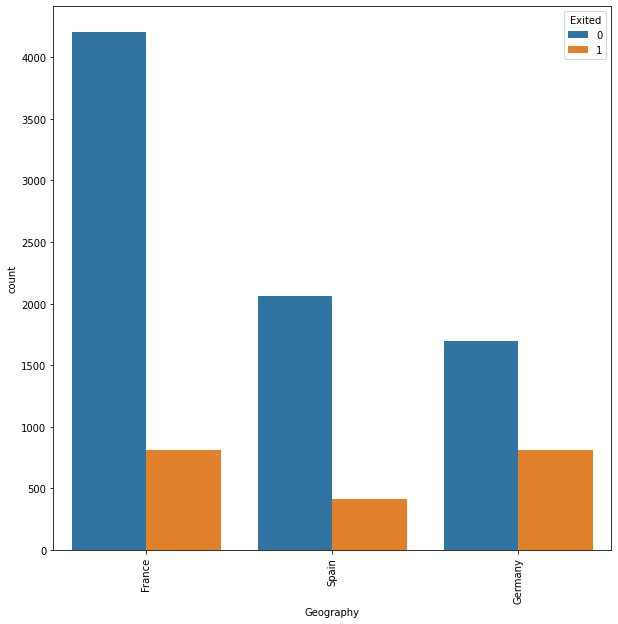

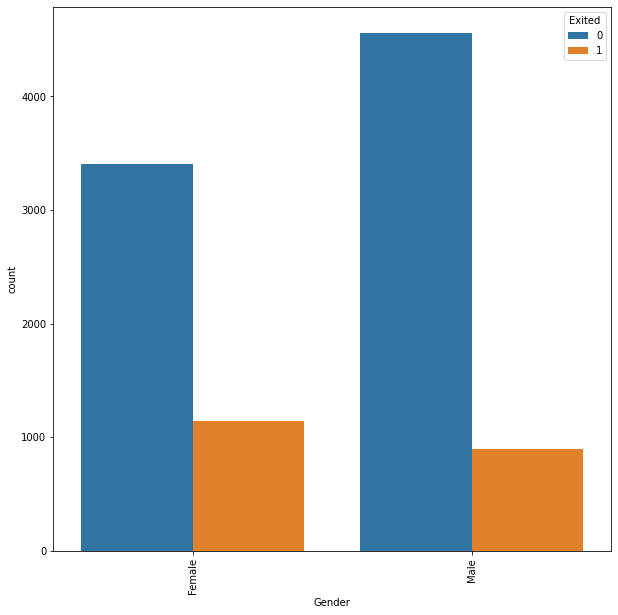

```python
for i in ['Geography', 'Gender' ]:
    plt.figure(figsize = (10,10))
    sns.countplot(df[i],hue='Exited', data=df)
    plt.xticks(rotation=90)
    plt.show()
```

```python
# Convert Geography as category variable to numeric values of 1, 2, & 3
df['Geography'] = df['Geography'].map({'France':1,'Spain':2, 'Germany':3})
df['Gender'] = df['Gender'].map({'Female':1,'Male':2})
```

```python
#Convert the numeric values to one hot code to remove the order
df = pd.get_dummies(df, columns=['Geography', 'Gender'])
```

```python
df.head()
```

|  | CreditScore | Age | Tenure | Balance | NumOfProducts | HasCrCard | IsActiveMember | EstimatedSalary | Exited | Geography_1 | Geography_2 | Geography_3 | Gender_1 | Gender_2 |
| --- | --- | --- | --- | --- | --- | --- | --- | --- | --- | --- | --- | --- | --- | --- |
| 0 | 619 | 42 | 2 | 0.00 | 1 | 1 | 1 | 101348.88 | 1 | 1 | 0 | 0 | 1 | 0 |
| 1 | 608 | 41 | 1 | 83807.86 | 1 | 0 | 1 | 112542.58 | 0 | 0 | 1 | 0 | 1 | 0 |
| 2 | 502 | 42 | 8 | 159660.80 | 3 | 1 | 0 | 113931.57 | 1 | 1 | 0 | 0 | 1 | 0 |
| 3 | 699 | 39 | 1 | 0.00 | 2 | 0 | 0 | 93826.63 | 0 | 1 | 0 | 0 | 1 | 0 |
| 4 | 850 | 43 | 2 | 125510.82 | 1 | 1 | 1 | 79084.10 | 0 | 0 | 1 | 0 | 1 | 0 |

## **4. Distinguish the feature and target set and divide the data set into training and test sets (5 points)**

```python
# Import `train_test_split` from `sklearn.model_selection`
from sklearn.model_selection import train_test_split

# Specify the data
df1 = df.drop('Exited', axis = 1)
X=df1.iloc[:,0:13]

# Specify the target labels and flatten array
y= df.Exited


# Split the data up in train and test sets
X_train, X_test, y_train, y_test = train_test_split(X, y, test_size=0.20, random_state=42)

y_train =  np.array(y_train)
y_test =  np.array(y_test)
```

```python
print(X_train.shape)
print(X_test.shape)
print(y_train.shape)
print(y_test.shape)
```

```
(8000, 13)
(2000, 13)
(8000,)
(2000,)
```

## **5. Normalize the train and test data (10points)**

```python
from sklearn.preprocessing import StandardScaler

sc = StandardScaler()

X_train = sc.fit_transform(X_train)
X_test = sc.transform(X_test)
```

## **6. Initialize & build the model. Identify the points of improvement and implement the same. (20)**

```python
# Using Tensorflow Keras instead of the original Keras

from tensorflow.keras import Sequential
from tensorflow.keras.layers import Dense
import tensorflow as tf
import tensorflow

from tensorflow import keras
from keras.layers import Dense

ncols = X_train.shape[0]

class MySequential(keras.models.Sequential):
  def __init__(self, **kwargs):
    super(MySequential, self).__init__(**kwargs)

  def predict_classes(self, x, batch_size=32, verbose=0):
    proba = self.predict(x, batch_size=batch_size, verbose=verbose)
    return (proba > 0.5).astype('int32')

def define_model():
    model = MySequential()
    model.add(keras.layers.Dense(256, activation = 'relu', input_shape=(13,)))

    opt = keras.optimizers.Adam(learning_rate = 0.00005)
    model.compile(loss='binary_crossentropy', optimizer=opt, metrics=['accuracy', 'mae', 'mse'])

    return model

# Test

model = define_model()


# second hidden layer
model.add(Dense(64, activation='relu'))
# third hidden layer
model.add(Dense(20, activation='relu'))

# Add an output layer with one neuron and no activation specified
model.add(Dense(1, activation = 'relu'))
```

```python
epochs = 50
```

```python
model.summary()
```

```
Model: "my_sequential"
_________________________________________________________________
Layer (type)                 Output Shape              Param #
=================================================================
dense (Dense)                (None, 256)               3584
_________________________________________________________________
dense_1 (Dense)              (None, 64)                16448
_________________________________________________________________
dense_2 (Dense)              (None, 20)                1300
_________________________________________________________________
dense_3 (Dense)              (None, 1)                 21
=================================================================
Total params: 21,353
Trainable params: 21,353
Non-trainable params: 0
_________________________________________________________________
```

```python
history = model.fit(X_train, y_train, epochs=epochs, validation_split = 0.2, verbose = False)

hist  = pd.DataFrame(history.history)
hist['epoch'] = history.epoch
print(hist)
```

```
        loss  accuracy       mae  ...   val_mae   val_mse  epoch
0   1.065032  0.793437  0.248477  ...  0.259652  0.150042      0
1   0.616537  0.793281  0.285048  ...  0.286851  0.142608      1
2   0.482739  0.795625  0.298585  ...  0.292048  0.138737      2
3   0.465382  0.798906  0.293585  ...  0.281536  0.135183      3
4   0.445629  0.801250  0.290057  ...  0.279142  0.133026      4
5   0.436716  0.806562  0.284988  ...  0.273594  0.130814      5
6   0.427920  0.809062  0.274807  ...  0.268710  0.128971      6
7   0.420587  0.813594  0.271235  ...  0.259935  0.127127      7
8   0.414225  0.815000  0.267229  ...  0.261968  0.125596      8
9   0.411628  0.814219  0.260474  ...  0.252879  0.127120      9
10  0.406252  0.815000  0.257220  ...  0.251911  0.125520     10
11  0.400700  0.817813  0.256155  ...  0.250834  0.124129     11
12  0.395016  0.822187  0.254014  ...  0.247200  0.122989     12
13  0.389840  0.824687  0.250017  ...  0.245110  0.121850     13
```

[output cut: 38 more lines]

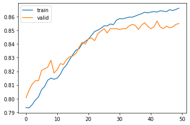

```python
import matplotlib.pyplot as plt

plt.plot(hist['accuracy'])
plt.plot(hist['val_accuracy'])
plt.legend(("train" , "valid") , loc =0)
```

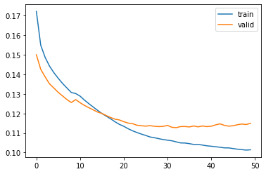

```python
# Plot of Mean Square Error

plt.plot(hist['mse'])
plt.plot(hist['val_mse'])
plt.legend(("train" , "valid") , loc =0)
```

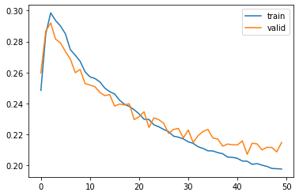

```python
plt.plot(hist['mae'])
plt.plot(hist['val_mae'])
plt.legend(("train" , "valid") , loc =0)
```

```python
results = model.evaluate(X_test, y_test)
```

```python
print(model.metrics_names)
print(results)
```

```
['loss', 'accuracy', 'mae', 'mse']
[0.4681786298751831, 0.8579999804496765, 0.21699610352516174, 0.11621304601430893]
```

## **Points of Improvement**

The accuracy of the test data is 0.858 which provides the best results so far. Various runs were made of the deep neural networks model with different values of hyperparameters, starting with different number of hidden layers and the number of neurons in each layer were varied. Removing the second and third hidden layer completely and trying different number of neurons as well as changing the number of epochs. In general the best results were observed with the currently set hyperparameters. The validation data vs. the training data values were observed. When the learning rate was higher the model was unstable and the validation scores varied up and down.

A step improvement in the model performance is observed when imbalance in the data set is removed. The accuracy reduces but there is significant improvement in the Recall score.

## **7. Predict the results using 0.5 as a threshold (10points)**

Keras implements predict_classes function with threshold value of 0.5 as follows:

```
def predict_classes(self, x, batch_size=32, verbose=0):

proba = self.predict(x, batch_size=batch_size, verbose=verbose)

if proba.shape[-1] > 1:

  return proba.argmax(axis=-1)

else:

  return (proba > 0.5).astype('int32')
```

### In the definition of MySelection the threshold has been entered as > 0.5

This was done to demonstrate that it was possible to set a customized threshold

```python
from sklearn.metrics import accuracy_score, confusion_matrix, precision_score
from sklearn.metrics import recall_score, f1_score, precision_recall_curve, auc

Y_pred_cls = model.predict_classes(X_test, batch_size=100, verbose=0)
```

## **8. Print the Accuracy score and confusion matrix (5 points)**

```python
print('Recall_score: ' + str(recall_score(y_test, Y_pred_cls)))
print('Precision_score: ' + str(precision_score(y_test, Y_pred_cls)))
print('F-score: ' + str(f1_score(y_test, Y_pred_cls)))
print()
confusion_matrix(y_test, Y_pred_cls)
```

```
Recall_score: 0.4580152671755725
Precision_score: 0.7171314741035857
F-score: 0.5590062111801242
```

```
array([[1536,   71],
       [ 213,  180]])
```

## **Observations**

In building the Deep Neural Network model, all the required steps were followed. Several combinations of hyper parameters were tried to improve the performance of the model using "accuracy" as the criteria. **The highest accuracy of 0.858** for the test data was obtained in this run. Confusion Matrix shows: TP = 180 ; TN = 1536 ; FN = 213 ; and FP = 71

The **precision score of 0.717 is quite good** because the FP are comparatively fewer. Model falsely predicts fewer customers who are likely to exit than the ones who actually exit.

It should be recognized that the **"Recall" score of 0.458** is not very good for the model and it may be because per the data set about 20% of customers have exited. Poor Recall score is because of the imbalance in the data set.

The **imbalance** in the data set could be corrected by upsampling the Exited customer data. I have implemented this solution in steps below called R5. You will see that using oversampling method to boost the imbalanced class has improved to Recall score and maintained the Precision score.

# **In the following steps, called R5 the model is re-constructed after implementing oversampling to remove the imbalance.**

## **4 (R5). Distinguish the feature and target set and divide the data set into training and test sets (5 points)**

## In revision R4, of the project it was observed that due to the imbalance in the data, the neural network provides low Recall score. In the major change implemented here, **oversampling technique** is used to boost the minority class which is the Exited customers.

```python
# import required modules
from sklearn.datasets import make_classification
from imblearn.over_sampling import RandomOverSampler

# define dataset

oversample = RandomOverSampler(sampling_strategy='minority')
x_over, y_over = oversample.fit_resample(X, y)
```

```python
# Split the data up in train and test sets
X_train, X_test, y_train, y_test = train_test_split(x_over, y_over, test_size=0.20, random_state=42)

y_train =  np.array(y_train)
y_test =  np.array(y_test)
```

```python
print(X_train.shape)
print(X_test.shape)
print(y_train.shape)
print(y_test.shape)
```

```
(12740, 13)
(3186, 13)
(12740,)
(3186,)
```

## **5 (R5). Normalize the train and test data (10points)**

```python
from sklearn.preprocessing import StandardScaler

# Define the scaler
scaler = StandardScaler().fit(X_train)

# Scale the train set
X_train = scaler.transform(X_train)

# Scale the test set
X_test = scaler.transform(X_test)
```

## **6 (R5). Initialize & build the model. Identify the points of improvement and implement the same. (20)**

```python
# Using Tensorflow Keras instead of the original Keras

from tensorflow.keras import Sequential
from tensorflow.keras.layers import Dense
import tensorflow as tf
import tensorflow

from tensorflow import keras
from keras.layers import Dense

ncols = X_train.shape[0]

class MySequential(keras.models.Sequential):
  def __init__(self, **kwargs):
    super(MySequential, self).__init__(**kwargs)

  def predict_classes(self, x, batch_size=32, verbose=0):
    proba = self.predict(x, batch_size=batch_size, verbose=verbose)
    return (proba > 0.5).astype('int32')

def define_model():
    model = MySequential()
    model.add(keras.layers.Dense(256, activation = 'relu', input_shape=(13,)))

    opt = keras.optimizers.Adam(learning_rate = 0.00005)
    model.compile(loss='binary_crossentropy', optimizer=opt, metrics=['accuracy', 'mae', 'mse'])

    return model

# Test

model = define_model()


# second hidden layer
model.add(Dense(64, activation='relu'))
# third hidden layer
model.add(Dense(20, activation='relu'))

# Add an output layer with one neuron and no activation specified
model.add(Dense(1, activation = 'relu'))
```

```python
epochs = 60
```

```python
model.summary()
```

```
Model: "my_sequential_2"
_________________________________________________________________
Layer (type)                 Output Shape              Param #
=================================================================
dense_8 (Dense)              (None, 256)               3584
_________________________________________________________________
dense_9 (Dense)              (None, 64)                16448
_________________________________________________________________
dense_10 (Dense)             (None, 20)                1300
_________________________________________________________________
dense_11 (Dense)             (None, 1)                 21
=================================================================
Total params: 21,353
Trainable params: 21,353
Non-trainable params: 0
_________________________________________________________________
```

```python
history = model.fit(X_train, y_train, epochs=epochs, validation_split = 0.2, verbose = False)

hist  = pd.DataFrame(history.history)
hist['epoch'] = history.epoch
print(hist)
```

```
        loss  accuracy       mae  ...   val_mae   val_mse  epoch
0   1.668219  0.554356  0.470062  ...  0.463293  0.255682      0
1   0.700705  0.615090  0.455367  ...  0.449616  0.229482      1
2   0.638307  0.650412  0.439417  ...  0.433459  0.214813      2
3   0.608316  0.679553  0.422815  ...  0.417687  0.204319      3
4   0.586721  0.699961  0.407737  ...  0.402972  0.195951      4
5   0.572304  0.709870  0.398987  ...  0.396503  0.191460      5
6   0.559295  0.718407  0.386985  ...  0.381466  0.185785      6
7   0.547092  0.722920  0.376220  ...  0.373335  0.181708      7
8   0.536031  0.731358  0.366257  ...  0.364103  0.178014      8
9   0.523399  0.737539  0.358362  ...  0.358255  0.174647      9
10  0.513658  0.746370  0.351887  ...  0.352828  0.171934     10
11  0.502556  0.754023  0.346229  ...  0.345966  0.168970     11
12  0.492587  0.760498  0.341057  ...  0.341763  0.166857     12
13  0.485695  0.765895  0.338358  ...  0.346812  0.165808     13
```

[output cut: 48 more lines]

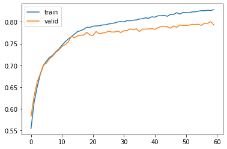

```python
import matplotlib.pyplot as plt

plt.plot(hist['accuracy'])
plt.plot(hist['val_accuracy'])
plt.legend(("train" , "valid") , loc =0)
```

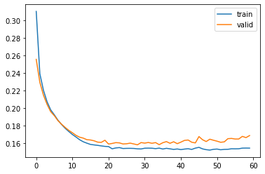

```python
# Plot of Mean Square Error

plt.plot(hist['mse'])
plt.plot(hist['val_mse'])
plt.legend(("train" , "valid") , loc =0)
```

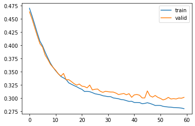

```python
plt.plot(hist['mae'])
plt.plot(hist['val_mae'])
plt.legend(("train" , "valid") , loc =0)
```

```python
results = model.evaluate(X_test, y_test)
```

```python
print(model.metrics_names)
print(results)
```

```
['loss', 'accuracy', 'mae', 'mse']
[0.4355981647968292, 0.8041431307792664, 0.30063459277153015, 0.17116594314575195]
```

## **Points of Improvement**

In R5 of the solution implemented, the accuracy of the test data is 0.804 which is less than the result without upsampling. Various runs were made of the deep neural networks model with different values of hyperparameters, starting with different number of hidden layers and the number of neurons in each layer were varied. Removing the second and third hidden layer completely and trying different number of neurons as well as changing the number of epochs. In general the best results were observed with the currently set hyperparameters. The validation data vs. the training data values were observed. When the learning rate was higher the model was unstable and the validation scores varied up and down.

Validation data tracks close to training data as the number of epochs are 60. There is slight overfitting observed but without loss of accuracy in the testing data.

When the imbalance in the data was removed by the use of oversampling technique in step 4, there was significant improvement in the model performance in terms of Recall score.

A step improvement in the model performance is observed when imbalance in the data set is removed. The accuracy reduced from 85.8% to 80.4% but the Recall score improved significantly.

## **7. Predict the results using 0.5 as a threshold (10points)**

Keras implements predict_classes function with threshold value of 0.5 as follows:

```
def predict_classes(self, x, batch_size=32, verbose=0):

proba = self.predict(x, batch_size=batch_size, verbose=verbose)

if proba.shape[-1] > 1:

  return proba.argmax(axis=-1)

else:

  return (proba > 0.5).astype('int32')
```

### In the definition of MySelection the threshold has been entered as > 0.5

This was done to demonstrate that it was possible to set a customized threshold

```python
from sklearn.metrics import accuracy_score, confusion_matrix, precision_score
from sklearn.metrics import recall_score, f1_score, precision_recall_curve, auc

Y_pred_cls = model.predict_classes(X_test, batch_size=100, verbose=0)
```

## **8. Print the Accuracy score and confusion matrix (5 points)**

```python
print('Recall_score: ' + str(recall_score(y_test, Y_pred_cls)))
print('Precision_score: ' + str(precision_score(y_test, Y_pred_cls)))
print('F-score: ' + str(f1_score(y_test, Y_pred_cls)))
print()
confusion_matrix(y_test, Y_pred_cls)
```

```
Recall_score: 0.8119768190598841
Precision_score: 0.7915881983678594
F-score: 0.8016528925619836
```

```
array([[1301,  332],
       [ 292, 1261]])
```

## **Observations**

In Revision 4 of the solution file, the imbalance correction step was not implemented. As a result the following results were observed:

## There was **imbalance** in the data set and it was improved by upsampling the Exited customer data. I have implemented this solution in this (R5) file.

- As a result **Recall score increased from 0.458 to 0.812.**
- At the same time, **Precision Score increased from 0.717 to 0.7915.**
- Most importantly, **F-score for the model increased from 0.559 to 0.801**

# Considering the business objectives of the bank it would help to have a model that more accurately predicts who is likely to exit the bank which is the Recall score.